# Visualize gender predictions based on census data

## Setups

```r
library(tidyverse)
library(lubridate)
library(wru)
source('utils/r-utils.R')
theme_set(theme_bw() + theme(legend.title = element_blank()))
```

## Load data

```r
alpha_threshold <- qnorm(0.975)

all_full_names <- read_tsv('data/names/full-names.tsv.xz') %>% distinct()
gender_df <- read_tsv('data/gender/genderize.tsv')
pubmed_gender_pmids <- read_tsv('data/names/corresponding-authors.tsv.xz') %>%
  left_join(read_tsv('data/pubmed/articles.tsv.xz'), by = 'pmid') %>%
  mutate(year = substr(publication_date, 1, 4) %>% ymd(truncated = 2),
         publication_date = ymd(publication_date, truncated = 2)) %>%
  left_join(gender_df, by = 'fore_name_simple')
pubmed_gender_df <- pubmed_gender_pmids %>%
  group_by(pmid, journal, publication_date, year) %>%
  summarise(probability_male = mean(probability_male, na.rm = T)) %>%
  ungroup()

pubmed_gender_pmids %>% filter(year < '2002-01-01', !is.na(fore_name_simple))
```

```
## # A tibble: 11 x 23
##      pmid pmcid.x position fore_name last_name corresponding
##     <dbl> <chr>      <dbl> <chr>     <chr>             <dbl>
##  1 1.10e7 PMC290…        1 Jeremy S  Edwards               1
##  2 1.10e7 PMC290…        2 Bernhard… Palsson               1
##  3 1.13e7 PMC313…        1 Jeffrey J Stewart               1
##  4 1.15e7 PMC352…        1 Janusz M  Bujnicki              1
##  5 1.15e7 PMC353…        1 Yu-Dong   Cai                   1
##  6 1.15e7 PMC373…        1 Colin W   Ward                  1
##  7 1.15e7 PMC553…        5 Arne      Elofsson              1
##  8 1.16e7 PMC577…        1 Jean-Mar… Buersted…             1
##  9 1.17e7 PMC585…        5 Lincoln   Stein                 1
## 10 1.17e7 PMC597…        2 Forest    Rohwer                1
## 11 1.18e7 PMC646…        2 Sean R    Eddy                  1
## # … with 17 more variables: reverse_position <dbl>, countries <chr>,
## #   source <chr>, use_last <dbl>, n_corresponding <dbl>,
## #   fore_name_simple <chr>, last_name_simple <chr>, pmcid.y <chr>,
## #   doi <chr>, journal <chr>, publication_date <date>, title <chr>,
## #   year <date>, n_authors <dbl>, genderize_sample_size <dbl>,
## #   query_date <date>, probability_male <dbl>
```

```r
iscb_gender_df <- read_tsv('data/iscb/keynotes.tsv') %>%
  mutate(publication_date = ymd(year, truncated = 2),
         year = ymd(year, truncated = 2)) %>%
  left_join(all_full_names, by = c('fore_name', 'last_name')) %>%
  left_join(gender_df, by = 'fore_name_simple') %>%
  filter(conference != 'PSB') # remove PSB
start_year <- 1993
end_year <- 2019
n_years <- end_year - start_year
my_jours <- unique(pubmed_gender_df$journal)
my_confs <- unique(iscb_gender_df$conference)
n_jours <- length(my_jours)
n_confs <- length(my_confs)

# unique names in iscb dataset:
iscb_gender_df %>%
  distinct(fore_name, last_name) %>%
  nrow()
```

```
## [1] 290
```

Between 2000-2001, 11 corresponding author names from 10 BMC Bioinformatics articles were retrieved from PMC.

Number of speakers/fellows in compbio conferences across years:

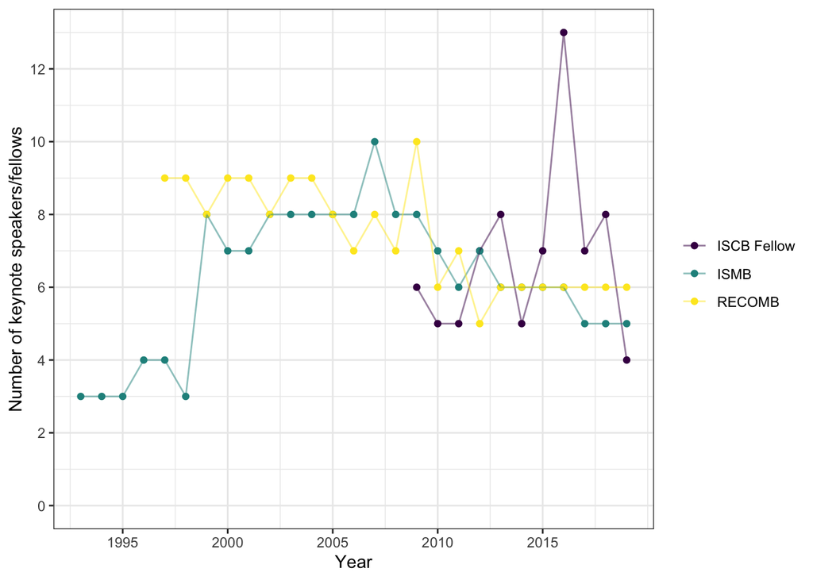

```r
iscb_gender_df %>%
  select(year, conference) %>%
  count(year, conference) %>%
  ggplot(aes(x = year(year), y = n, color = conference)) +
  geom_point() +
  geom_line(alpha = 0.5) +
  coord_cartesian(ylim = c(0, 13)) +
  scale_x_continuous(breaks = seq(1995, 2019, 5)) +
  scale_y_continuous(breaks = seq(0, 14, 2)) +
  scale_color_viridis_d() +
  labs(x = 'Year', y = 'Number of keynote speakers/fellows')
```

## Missing data

```r
iscb_gender_df %>% filter(is.na(probability_male))
```

```
## # A tibble: 3 x 16
##   year       full_name.x fore_name last_name conference source affiliations
##   <date>     <chr>       <chr>     <chr>     <chr>      <chr>  <chr>
## 1 1997-01-01 Marcie McC… Marcie    McClure   ISMB       https… University …
## 2 2003-01-01 Árpád Furka Árpád     Furka     RECOMB     https… Eötvös Lorá…
## 3 2013-01-01 Chung-I Wu  Chung-I   Wu        RECOMB     <NA>   Beijing Ins…
## # … with 9 more variables: afflcountries <chr>, publication_date <date>,
## #   fore_name_simple <chr>, last_name_simple <chr>, full_name.y <chr>,
## #   n_authors <dbl>, genderize_sample_size <dbl>, query_date <date>,
## #   probability_male <dbl>
```

```r
pubmed_gender_pmids %>% filter(is.na(probability_male)) %>% sample_n(10)
```

```
## # A tibble: 10 x 23
##      pmid pmcid.x position fore_name last_name corresponding
##     <dbl> <chr>      <dbl> <chr>     <chr>             <dbl>
##  1 2.78e7 PMC509…        3 Maozu     Guo                   1
##  2 1.56e7 <NA>           2 T J       Naughton             NA
##  3 2.18e7 PMC313…        8 Sündüz    Keleş                 1
##  4 1.10e7 <NA>           5 Y         Akiyama              NA
##  5 3.09e7 <NA>           5 Xu-Cheng  Yin                  NA
##  6 2.83e7 PMC534…        9 Zhao-xia… Bian                  1
##  7 2.11e7 PMC303…        2 Veerabha… Baladand…             1
##  8 1.10e7 <NA>           2 G H       Gonnet               NA
##  9 2.16e7 PMC312…        1 Ren-Hua   Chung                 1
## 10 2.68e7 PMC484…        1 S. H.     Lee                   1
## # … with 17 more variables: reverse_position <dbl>, countries <chr>,
## #   source <chr>, use_last <dbl>, n_corresponding <dbl>,
## #   fore_name_simple <chr>, last_name_simple <chr>, pmcid.y <chr>,
## #   doi <chr>, journal <chr>, publication_date <date>, title <chr>,
## #   year <date>, n_authors <dbl>, genderize_sample_size <dbl>,
## #   query_date <date>, probability_male <dbl>
```

```r
sum(is.na(pubmed_gender_pmids$probability_male))
```

```
## [1] 3089
```

```r
# 45 corresponding authors with empty fore name field (i.e., missing metadata)
pubmed_gender_pmids %>%
  filter(is.na(fore_name)) %>%
  nrow()
```

```
## [1] 45
```

```r
# 1466 corresponding authors with fore name that is None once simplified (i.e., initials only)
pubmed_gender_pmids %>%
  filter(!is.na(fore_name)&is.na(fore_name_simple)) %>%
  nrow()
```

```
## [1] 1466
```

```r
# 1578 corresponding authors with fore name but no predictions
# 52% has a dash
pubmed_gender_pmids %>%
  filter(is.na(probability_male) & !is.na(fore_name_simple)) %>%
  mutate(dashed_name = grepl('-', fore_name_simple)) %>%
  count(dashed_name)
```

```
## # A tibble: 2 x 2
##   dashed_name     n
##   <lgl>       <int>
## 1 FALSE         757
## 2 TRUE          821
```

```r
# 30961 predicted names
pubmed_gender_pmids %>%
  filter(!is.na(probability_male)) %>%
  nrow()
```

```
## [1] 30961
```

```r
# mean probability of selecting Asian among these names: 80%
pubmed_gender_pmids %>%
  filter(is.na(probability_male) & !is.na(fore_name_simple)) %>%
  rename('surname' = last_name_simple) %>%
  predict_race(surname.only = T, impute.missing = F) %>%
  pull(pred.asi) %>%
  mean(na.rm = T)
```

```
## [1] "Proceeding with surname-only predictions..."
```

```
## [1] 0.7940528
```

3 iscb forenames not genderized (Marcie, Árpád and Chung-I). These NA predictions mostly include initials only, hyphenated names and perhaps names with accent marks.

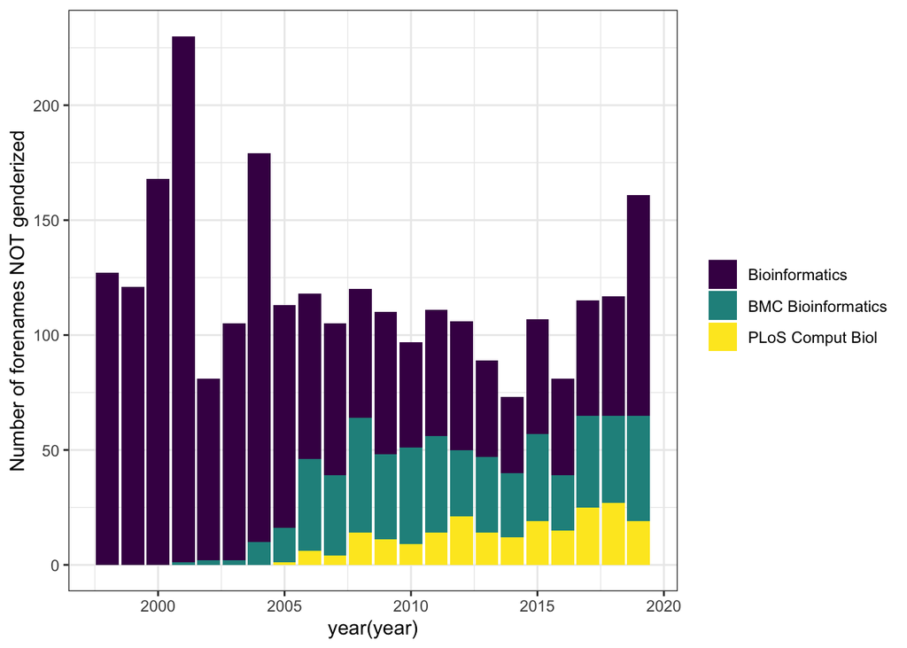

```r
pubmed_gender_df %>% filter(is.na(probability_male)) %>%
  count(year, journal) %>%
  ggplot(aes(year(year), n, fill = journal)) +
  geom_bar(stat = 'identity') +
  scale_fill_viridis_d() +
  ylab('Number of forenames NOT genderized')
```

```r
pubmed_gender_pmids %>%
  filter(is.na(probability_male),
         journal == 'BMC Bioinformatics',
         year < '2002-01-01')
```

```
## # A tibble: 1 x 23
##     pmid pmcid.x position fore_name last_name corresponding
##    <dbl> <chr>      <dbl> <chr>     <chr>             <dbl>
## 1 1.15e7 PMC353…        1 Yu-Dong   Cai                   1
## # … with 17 more variables: reverse_position <dbl>, countries <chr>,
## #   source <chr>, use_last <dbl>, n_corresponding <dbl>,
## #   fore_name_simple <chr>, last_name_simple <chr>, pmcid.y <chr>,
## #   doi <chr>, journal <chr>, publication_date <date>, title <chr>,
## #   year <date>, n_authors <dbl>, genderize_sample_size <dbl>,
## #   query_date <date>, probability_male <dbl>
```

## Prepare data frames for later analyses

- rbind results of race predictions in iscb and Pubmed
- pivot long
- compute mean, sd, marginal error

```r
iscb_pubmed <- iscb_gender_df %>%
  rename('journal' = conference) %>%
  select(year, journal, probability_male, publication_date) %>%
  mutate(type = 'Keynote speakers/Fellows') %>%
  bind_rows(
    pubmed_gender_df %>%
      select(year, journal, probability_male, publication_date) %>%
      mutate(type = 'Pubmed authors')
  ) %>%
  mutate(probability_female = 1 - probability_male) %>%
  pivot_longer(contains('probability'),
               names_to = 'gender',
               values_to = 'probabilities') %>%
  group_by(type, year, publication_date, gender) %>%
  add_count() %>%
  mutate(
    mean_prob = mean(probabilities, na.rm = T),
    sd_prob = sd(probabilities, na.rm = T),
    n = mean(n),
    me_prob = alpha_threshold * sd_prob / sqrt(n)
  ) %>%
  ungroup()
```

## Prepare data frames for analysis

### By journals

```r
pubmed_gender <- vector('list', length = n_jours)
i <- 0

for (jour in my_jours){
  i <- i + 1
  pubmed_gender[[i]] <- iscb_pubmed %>%
    filter(type == 'Pubmed authors' & journal == jour) %>%
    group_by(year, gender, journal) %>%
    summarise(mean_prob = mean(probabilities, na.rm = T)) %>%
    ungroup()
}
```

### By conference keynotes/fellows

```r
i <- 0
iscb_gender <- vector('list', length = n_confs)

for (conf in my_confs){
  i <- i + 1
  iscb_gender[[i]] <- iscb_pubmed %>%
    filter(type != 'Pubmed authors' & journal == conf) %>%
    group_by(year, gender, journal) %>%
    summarise(mean_prob = mean(probabilities, na.rm = T)) %>%
    ungroup()
}
```

## Figures for paper

### Figure 1: ISCB Fellows and keynote speakers appear more evenly split between men and women than PubMed authors, but the proportion has not reached parity.

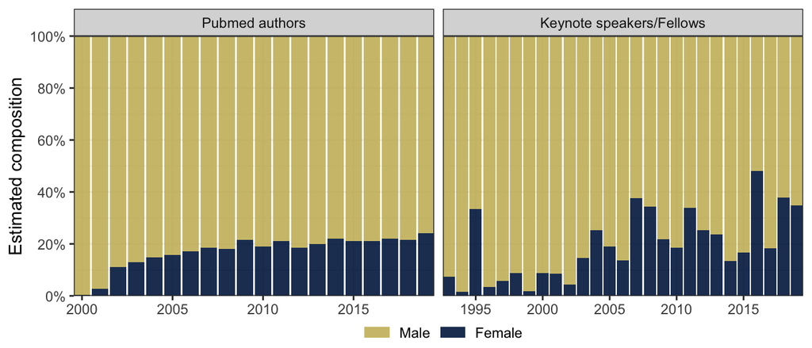

```r
fig_1 <- iscb_pubmed %>%
  filter(year < '2020-01-01') %>%
  group_by(year, type, gender) %>%
  summarise(mean_prob = mean(probabilities, na.rm = T)) %>%
  ungroup() %>%
  gender_breakdown('main', fct_rev(type))
fig_1
```

```r
ggsave('figs/gender_breakdown.png', fig_1, width = 5, height = 2.5)
f_df <- iscb_pubmed %>% filter(gender == 'probability_female', !is.na(probabilities))
f_pub <- f_df %>% filter(type == 'Pubmed authors') %>% pull(probabilities)
f_iscb <- f_df %>% filter(type != 'Pubmed authors') %>% pull(probabilities)

t.test(f_iscb, f_pub) %>%
  broom::tidy() %>%
  select(-contains('estimate')) %>%
  print()
```

```
## # A tibble: 1 x 7
##   statistic p.value parameter conf.low conf.high method         alternative
##       <dbl>   <dbl>     <dbl>    <dbl>     <dbl> <chr>          <chr>
## 1     0.753   0.452      418.  -0.0222    0.0498 Welch Two Sam… two.sided
```

### Supplementary Figure S1

Increasing trend of honorees who were women in each honor category, especially in the group of ISCB Fellows, which markedly increased after 2015.

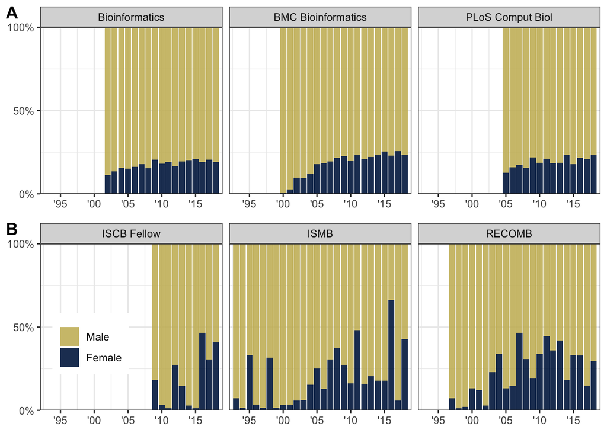

```r
# By journal:
fig_1c <- bind_rows(pubmed_gender) %>%
  gender_breakdown(category = 'sub', journal)

# By conference:
fig_1d <- bind_rows(iscb_gender) %>%
  gender_breakdown(category = 'sub', journal) +
  theme(legend.position = c(0.09, 0.4))

fig_s1 <- cowplot::plot_grid(fig_1c, fig_1d, labels = 'AUTO', ncol = 1)
fig_s1
```

```r
ggsave('figs/fig_s1.png', fig_s1, width = 6, height = 3.5)
```

## Overview of gender prediction distribution

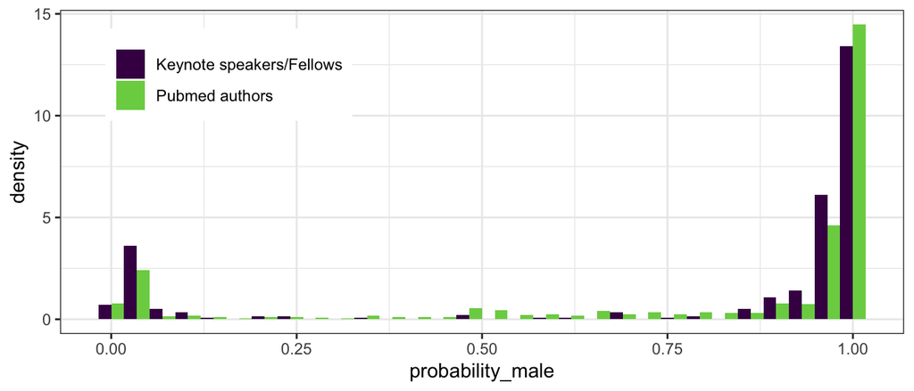

```r
iscb_pubmed %>%
  filter(gender == 'probability_male') %>%
  ggplot(aes(x = probabilities, y = ..density.., fill = type)) +
  geom_histogram(position = 'dodge') +
  scale_fill_viridis_d(option = 'D', end = 0.8) +
  guides(label = F) +
  labs(x = 'probability_male') +
  theme(legend.position = c(0.2, 0.8))
```

## Mean and standard deviation of predicted probabilities

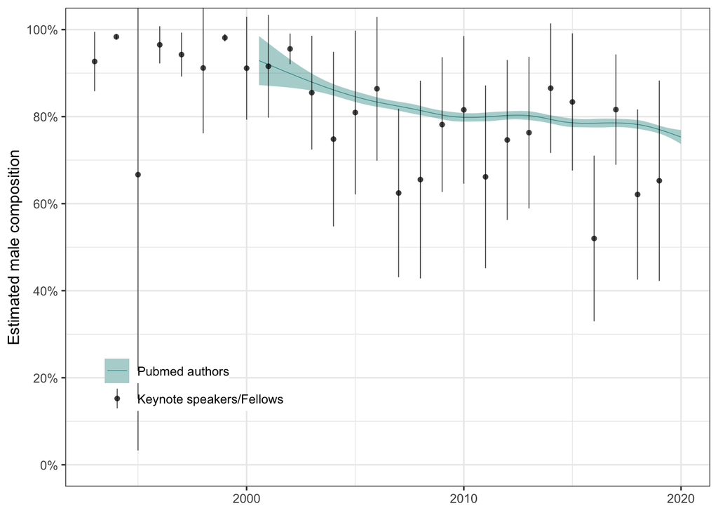

```r
ggplot(iscb_pubmed %>% filter(gender == 'probability_male'),
  aes(group = type)) +
  geom_smooth(size = 0.2, data = . %>% filter(type == 'Pubmed authors'),
              aes(x = publication_date, y = probabilities, fill = type, color = type)) +
  geom_pointrange(data = . %>% get_keynote_summary(),
                  alpha = 0.75, size = 0.3,
                  aes(x = year, y = mean_prob, shape = type,
                      ymin = mean_prob - me_prob,
                      ymax = mean_prob + me_prob)) +
  scale_y_continuous(breaks = seq(0, 1, 0.2), labels = scales::percent_format()) +
  scale_x_date(labels = scales::date_format("%Y")) +
  scale_color_viridis_d(option = 'D', begin = 0.5) +
  scale_fill_viridis_d(option = 'D', begin = 0.5) +
  coord_cartesian(ylim = c(0, 1)) +
  labs(x = NULL, y = 'Estimated male composition') +
  theme(legend.position = c(0.2, 0.2),
        legend.margin = margin(-0.5, 0, 0, 0, unit='cm'))
```